# BSAN2204

Tutorial 1 - Introduction

## What we do in BSAN2204 tutorials…

The tutorials in BSAN2204 apply the lecture content through a series of practical exercises. The tutorials require your active hands on keyboard participation. To some extent (although not completely), your completion of the tutorial exercises will provide you with a template file you can use/adapt for the second and third assignments.

We will be writing code in `R`.

We will troubleshooting code for your BSAN2204 assessments

We will be getting to know each other!

## Introductions

Icebreakers can be tricky, but they are a fun way to connect with peers, spark conversations, and make new friends. I will go first:

My name is `name`. I am from `city`.

The most recent song I listened to is `song`.

I come to campus by `travel_mode` because `reason`.

…now turn to someone sitting nearby, ideally someone you do **not** already know. Introduce yourself using the above facts about yourself!

## Thinking like a programmer

On the previous slide, we defined values for the variables `name`, `city` , `song`, `travel_mode` and `reason`.

Think of your individual conversation as like individual “sessions” with your conversation partner. For the conversation to go smoothly, you need to agree upon the respective values of the above variables. One assigned, the values sit in your short term memory for easy retrieval later (hopefully!).

The values of these variables can change, and this has flow on effects. For example, if you suddenly change your story and tell your neighbour that actually, your name is different, or the way you travelled to campus has changed… this might change how “the program” (i.e., the conversation) works if your answers somehow affect their behaviour.

This is all a bit silly and forced, but thinking this way is essentially how we will approach writing code this semester!

## Introduce your neighbour

Most people will hold back from revealing too much about themselves at first which is why we have these icebreakers to give you some structure.

Introducing other people though is a very different thing. When introducing someone you will usually be more motivated to find a common interest between the people you are bringing together.

…turn to someone nearby (could be someone you **do** already know), and introduce the person you just met. (This requires retrieving that values for the variables they set during your earlier conversation!)

Find what things they have in common!

## Helping each other in BSAN2204

This course can be tricky sometimes. You *will* encounter problems in your R code that will be hard to solve… this is all part of the journey of learning `R`. Having others nearby to help troubleshoot problems together will both save your sanity and build connections. **Helping others solidifies and affirms your own knowledge, too**.

## Software in BSAN2204

We will be using `R` in R Studio. R is a computing environment and language for statistical analysis and graphics. It is one of the most popular platforms for data analysis and visualisation.

**R is free** open-source software supported by a vibrant user community.

Download and install the latest version of `R` from:  
**https://cran.csiro.au/**

Download and install the latest version of R Studio from:  
**https://posit.co/products/open-source/rstudio/#Desktop**

## R and R Studio

`R` as a programming language needs to be written in a text-editor. RStudio is an editor specifically optimised for working with `R`. RStudio is also free and open-source. It provides several integrated tools to help you organise your `R` projects within a graphical user interface.

**It has four main windows:**

1. The script editor (where you write your code)
2. The console (where code is executed/output)
3. Tabs for your workspace
4. Tabs for your files, plots, packages, help, viewer, and presentations

**Let’s get started by creating our first file.** If it isn’t there already select File -> New File -> R Script from the menu bar at the top of the screen. This will open a new script editor window.

## R Studio layout

[figure not shown]

## R Studio script editor

The script editor window is the interface where you can write, edit, and execute code. Lines can be executed using simple keyboard short cuts (`ctrl/cmd+enter`) or clicking on the “Run” button.

Click the “copy to clipboard” icon which appears to the right of the code upon hovering your cursor. Run the code in R Studio on your computer.

```r
age <- c(1, 3, 5, 2, 11, 9, 3, 9, 12, 3)
```

This code assigns a vector of numbers to an object called `age`. Upon execution (using `ctrl/cmd+enter` or clicking “Run”) the object is saved to the environment as a value.

## Saving your R script

Click the save icon 💾 within the R script window to save your R script. R script files are saved with the `.r` file extension. Later we will work with `.Rmd` files (R Markdown).

Think of this file as your “project file”. For the BSAN2204 assignments you should have just one file per project.

**Keep this file saved somewhere you can easily find it! The most logical place would be a …/BSAN2204/ folder somewhere on your computer.**

This location will become your “working directory” (more on this later…)

## R Console

The R Console is where the outputs of code executed from the R Script window appears. Not all code generates output (e.g., when we assigned values to `age` nothing appeared in the console). The console is also where error messages will appear if encountered. Try running the following code:

```r
print(weight)
```

Running this code will output an error message in the console, because we have not created any object called `weight`.

Warning: Code executed directly in the console is not saved! Only use the console for code you want to run once (e.g., installing packages).

## R Studio environment

The environment tab is one of several in this section of R Studio, but it is probably the only tab within this section of R Studio you will ever use. Notice here that the object `age` created from the code on the previous slide appears as a value here.

[figure not shown]

## Cleaning your workspace

Over time, the environment tab can become cluttered with objects you do not need (created while drafting your report). You should aim to keep both your script editor and your workspace *clean* (keeping only necessary lines of code, and necessary objects within your environment).

To remove individual objects, use the `rm()` function. For example:

```r
remove(age)
```

This removes the object `age` from the environment. If you just want to update the contents of what is in `age` you can run assigns values to it again to override whatever is currently stored in the object.

## Clearing the workspace

Another way to clean your workspace is to sweep it entirely by clicking on the broom icon (🧹) to clear all objects from the workspace.

Be aware that sweeping your workspace clean means you will need to re-run all of your code from the start in order to bring back your needed objects (especially external data files you read in).

It is important to keep your R script neat and tidy, so that when you (or someone else) runs your script from start to finish it sets up your workspace environment as intended.

## Saving your workspace

At the end of a tutorial, or session working in `R` it is a good idea to save your workspace. Click the save icon (💾) under the environment tab to save the workspace as a `.RData` file.

This is not as essential as saving your `.r`/`.Rmd` file, but it is certainly a good idea! The primary purpose of saving the workspace is to allow you to easily resume your work in a future R session without having to re-create or re-load all of your objects from your `.r` or `.Rmd` file.

## Other R Studio windows

1. **Files** – Used to navigate your computer to find files to load or to set your working directory.
2. **Plots** – Displays graphs and visualisations generated from your R script.
3. **Packages** – Shows which add-ons are loaded and allows you to install new packages.
4. **Help** – Contains documentation for all available packages and commands in `R`.
5. **Viewer** and **Presentation** – Used when creating dashboards (with `R Shiny`) or presenting slides (with `R Quarto`). These will be used in future BSAN courses.

## R Packages

`R` comes preloaded with many “base” packages. We will be installing many additional packages that have been contributed to by the open-source community that extend the functionality of base `R`.

To install packages, click install within the Packages tab, search for the required package name, and click Install. R Studio will execute the `install.packages()` command in the console window “for you”.

Do not include `install.packages()` inside your `.r` or `.Rmd` file as this will lead you to re-install/update packages every time you run your code!

## Working directory

Each `R` session has a defined working directory. An R working directory is the folder location on the file system from which `R` reads and writes files by default during an R session. Check where your current working direct is by typing `getwd()` into the console window.

Your working directory should be where you save your `.r` or `.Rmd` file, i.e., the …/BSAN2204/ folder somewhere on your computer.

If RStudio is launched by directly opening a `.r` file (e.g., by double-clicking it in a file browser), R Studio will typically set the working directory to the directory containing that `.r` file.

## Setting the working directory

If for some reason your working directory is not set to where it should be, navigate to it (e.g. your …/BSAN2204/ folder) in the Files tab, click “More” then click “Set As Working Directory”.

Alternatively, right click the `.r` or `.Rmd` file you have open in your R script editor and choose “Set Working Directory”.

Not having your working directly set correctly is often the first error students encounter when attempting to load the `MSD.Rdata` file for their assignment! When you download this file from Blackboard… save it to your working directory!

## Staying organised

By now you should have created a *…/BSAN2204/* folder somewhere on your computer, saved your first `.r` file there, and maybe even downloaded the `MSD.RData` there too.

Keep all your BSAN2204 here. Do not create too many different “versions” of your working project and if things stop working “randomly” come back to this folder and check that it is set as your working directory.

Treat your `.r` or `.Rmd` file like a draft document. Delete unnecessary lines of code so that you do not have conflicting objects in your environment.

Keep your environment window tidy. Occasionally sweep it clear using the broom (🧹).

## A quick `R` session

First, clear the workspace of any existing objects. We do not need `age` for this session. We will create a complete new set of variables to work with related to business analytics.

Copy the code below into your script editor window and run it.

```r
uq_transport <- data.frame(
  mode = c("Bus", "Ferry", "Train", "Car", "Bicycle", "Walking"),
  arrivals = c(31429, 5714, 2857, 8571, 5714, 2857)
)
```

This creates a data frame with counts of the number of arrivals on campus by travel mode. The data is based on estimates obtained from: https://www.data.qld.gov.au/dataset?tags=public%20transport.

## UQ Transport Data

We now have a data frame in our environment called `uq_transport`. We can access the two variables (columns) within it using the `$` operator like this: `uq_transport$mode` and `uq_tranpsort$arrivals`. We can open it and view it like a spreadsheet by clicking the icon next to it in the environment window.

Let’s answer some *very basic* questions about this dataframe by utilising some basic `R` syntax commands.

## UQ Transport Data

What is the total number of arrivals on campus by public transport? We will extract the data from the data frame as separate values and then add them all up. It is not the most elegant solution, but it demonstrates of some very basic `R` syntax (we will explore other methods in the next session).

`<-` is used to assign values to an object  
`$` is used to refer to a particular variable within a dataframe  
`[]` is used to subset a dataframe  
`==` is used to check a logical condition

```r
bus_arrivals   <- uq_transport$arrivals[uq_transport$mode == "Bus"]
ferry_arrivals <- uq_transport$arrivals[uq_transport$mode == "Ferry"]
train_arrivals <- uq_transport$arrivals[uq_transport$mode == "Train"]

total_public_arrivals <- bus_arrivals + ferry_arrivals + train_arrivals

print(total_public_arrivals)
```

```
[1] 40000
```

## UQ Transport Data

Most people at UQ take the bus to campus!

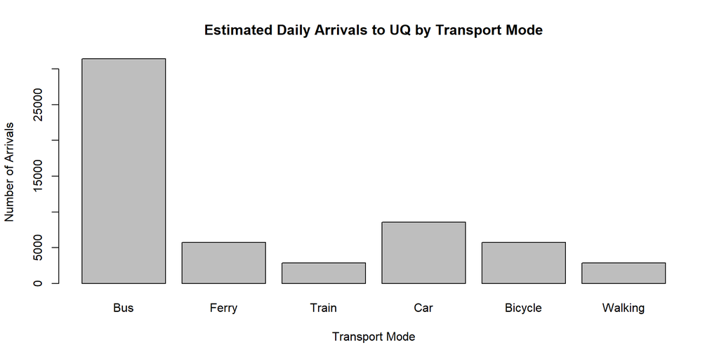

```r
barplot(uq_transport$arrivals,
        names.arg = uq_transport$mode,
        main = "Estimated Daily Arrivals to UQ by Transport Mode",
        ylab = "Number of Arrivals",
        xlab = "Transport Mode")
```

## The BSAN2204 assessments

R Skills Tutorial Quiz (A1)

Predictive Analytics Report (A2)

Practical Demonstration (A3)

A1 will occur during tutorials as an offline paper and pen quiz,

A2 is completed in your own time and submitted online and,

A3 is completed as an end of semester open book/laptop exam.

## R Skills Tutorial Quiz (A1)

The quiz will be entirely multiple choice, and will test core R knowledge and concepts. You can expect several of the concepts introduced today to appear on the A1 quiz. For example, questions about difference between R and R Studio, your understanding of the R Studio (default) layout, how R packages work, setting a working directory, loading files.

Some questions will show examples of R code, and your task will be to indicate which output it produces.

Other questions will show examples of R output, and your task will be to indicate which R code generated it.

This assignment will be completely **offline**, it will be completed by paper and pen in tutorials. You will not have access to the Internet, AI or any other tools (other than your own mind!).

## Predictive Analytics Report (A2)

The report will bring together everything taught in the lectures and tutorials into one report. It requires you to analyse a dataset provided on BlackBoard (the `MSD.RData`).

Throughout tutorials, we will progressively work together on building a basic template that gets you most of the way towards completing the report (although not entirely!). Submitting the template we build in class should be sufficient for a passing grade in most instances, or higher middling grades when some basic tweaks are made.To do well (i.e., “get a 7”) on this report, you need to add your own personal touches to this report. At the most basic level, this just means customising the template we build in class (choosing different variables, choosing different defaults, and importantly *explaining your choices*).

It is *totally fine* to use AI for this assignment. You can use AI tools for writing and troubleshooting your code, but relying entirely on AI tools is not advised (you should attempt as much as possible to “know your code”).

## Practical Demonstration (A3)

This assignment will essentially require you to reproduce a report that is similar to the Predictive Analytics Report (A2), but using a **different dataset**. This task will completed under exam conditions (2 hours, on campus, in person, invigilated by course staff), but you will have full access to the Internet, AI tools, and your own device (laptop).

Using AI tools to complete this assignment is *strongly encouraged* as these will greatly improve your ability to produce a polished business analytics report within a short timeframe.

This assignment is designed to mirror the expectations you will face in industry (being asked to turn around a quick analysis of some data in a short amount of time using AI).

## That’s all for now!

Today we introduced ourselves and had our first introduction to working in `R`. We are starting slow, learning the fundamental basics of how to use the software first before we jump into more applied work using real data.

In the next session we will work through some more basic `R` exercises, focussing on building good habits like ensuring we always assign values to objects, rather than outputting directly to the R console.

## Questions?

If you have any further questions after class, please see me during my consultation time by booking a time via the links available on BlackBoard.

Thank you!